# Mert Erdinc BADS Final Assignment

#### Item Size Numeric

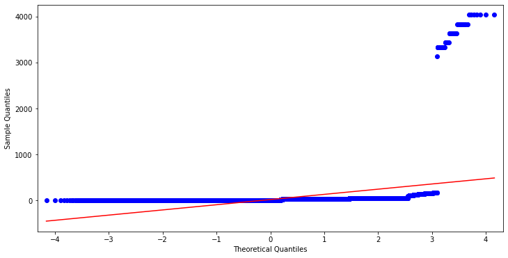

```python
qqplot(dfk_train.item_size_num, line='s')
plt.show()
```

```python
bc_fitted_feature, bc_fitted_lambda = stats.boxcox(dfk_train.item_size_num+1)
bc_fitted_lambda
```

```
-0.2002079885868404
```

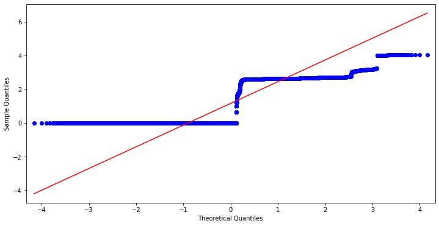

```python
qqplot(bc_fitted_feature, line='s')
plt.show()
```

```python
print(bc_fitted_feature.mean())
print(dfk_train.item_size_num.mean())
```

```
1.1559982
20.847150802612305
```

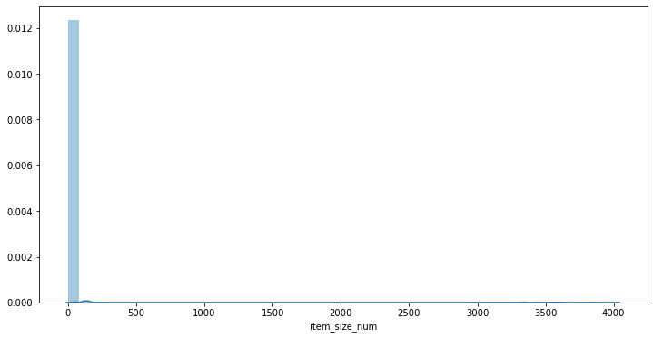

```python
sns.distplot(dfk_train.item_size_num);
```

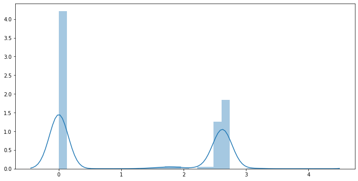

```python
sns.distplot(bc_fitted_feature);   #somewhat better with the normalized version
```

```python
print(stats.normaltest(dfk_train.item_size_num))
print(stats.normaltest(bc_fitted_feature))
```

```
NormaltestResult(statistic=162534.7155320478, pvalue=0.0)
NormaltestResult(statistic=227132.04784745874, pvalue=0.0)
```

The test values doesn't help making decisions and the quantile plot wasn't very clear either. Since the density plots suggested the normalized version of the variable, it would be normalized.

#### Order Day

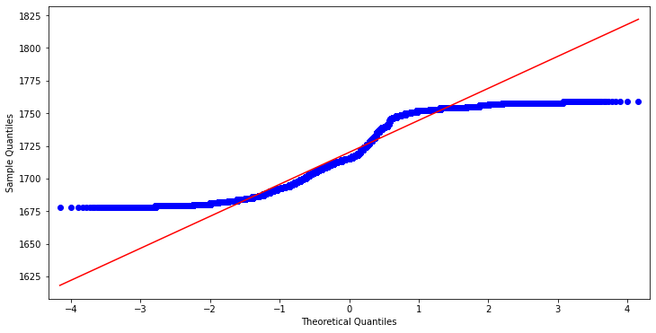

```python
qqplot(dfk_train.order_day, line='s')
plt.show()
```

```python
dfk_train[dfk_train.order_day == 0]
```

|  | item_id | item_color | brand_id | item_price | user_title | user_state | return | user_age | user_reg_time | order_day | delivery_day | delivery_dur | item_size_cat | item_size_num |
| --- | --- | --- | --- | --- | --- | --- | --- | --- | --- | --- | --- | --- | --- | --- |

```python
bc_fitted_feature, bc_fitted_lambda = stats.boxcox(dfk_train.order_day) #No zeros in the variable so we don't need to add plus 1 here
bc_fitted_lambda
```

```
-18.944271593086487
```

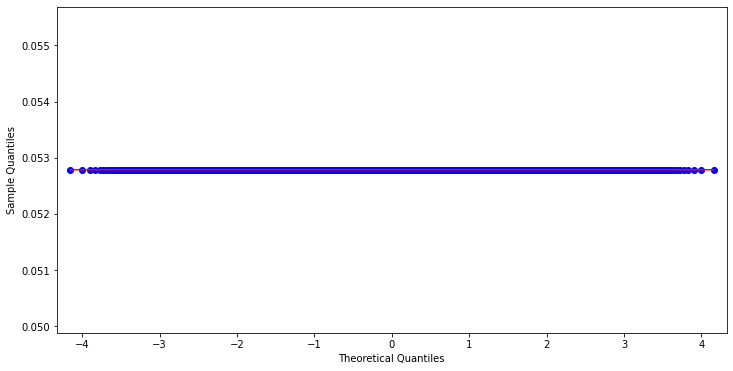

```python
qqplot(bc_fitted_feature, line='s')    #this method renders the variable useless so it won't be used.
plt.show()
```

#### User Age

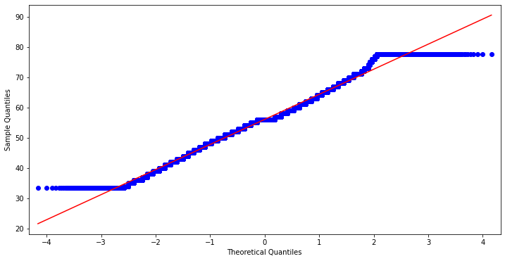

```python
qqplot(dfk_train.user_age, line='s')
plt.show()
```

```python
bc_fitted_feature, bc_fitted_lambda = stats.boxcox(dfk_train.user_age) #No 0's in the column
bc_fitted_lambda
```

```
0.771480589917256
```

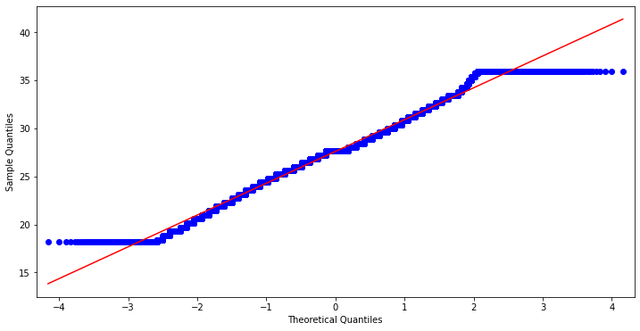

```python
qqplot(bc_fitted_feature, line='s')
plt.show()
```

```python
print(bc_fitted_feature.mean())
print(dfk_train.user_age.mean())
```

```
27.594027
56.03813552856445
```

```python
print(stats.normaltest(dfk_train.user_age))   #in practice there is no difference so to keep the variable as the original,
print(stats.normaltest(bc_fitted_feature))    #no change will be made.
```

```
NormaltestResult(statistic=381.91193188134446, pvalue=1.1718653293253487e-83)
NormaltestResult(statistic=211.28717643199607, pvalue=1.3169600151264255e-46)
```

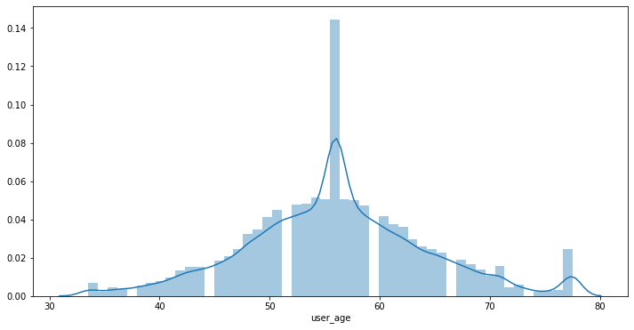

```python
sns.distplot(dfk_train.user_age);
```

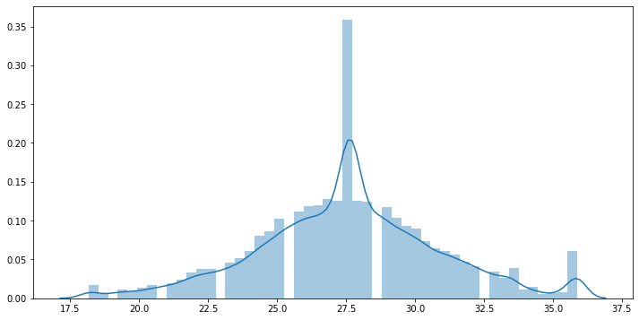

```python
sns.distplot(bc_fitted_feature); #as the graphs, statistics suggested there is no significant difference but if every
                                 #variable was normalized to avoid creating imbalance between how the variables are treated,
                                 #this variable would be normalized too
```

#### User Registration Time

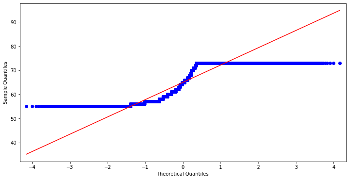

```python
qqplot(dfk_train.user_reg_time, line='s')
plt.show()
```

```python
bc_fitted_feature, bc_fitted_lambda = stats.boxcox(dfk_train.user_reg_time) #No 0's in the variable
bc_fitted_lambda
```

```
0.8747309084848859
```

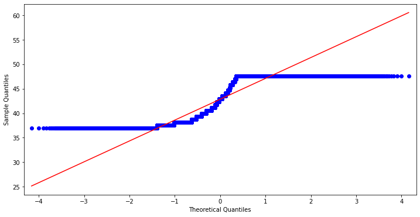

```python
qqplot(bc_fitted_feature, line='s') #no big difference, if other variables were normalized this one would be too.
plt.show()
```

```python
print(stats.normaltest(dfk_train.user_reg_time))   #no difference statistics-wise.
print(stats.normaltest(bc_fitted_feature))
```

```
NormaltestResult(statistic=270263.2982905261, pvalue=0.0)
NormaltestResult(statistic=271247.91987112525, pvalue=0.0)
```

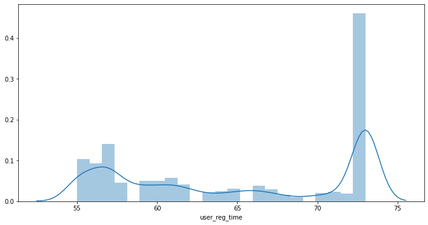

```python
sns.distplot(dfk_train.user_reg_time);
```

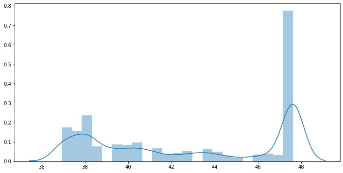

```python
sns.distplot(bc_fitted_feature); #not much difference
```

#### Scalization

```python
dfk_train.describe() #to compare before and after scalization
```

|  | item_price | return | user_age | user_reg_time | order_day | delivery_day | delivery_dur | item_size_num |
| --- | --- | --- | --- | --- | --- | --- | --- | --- |
| count | 62565.000000 | 62565.000000 | 62565.000000 | 62565.000000 | 62565.000000 | 62565.000000 | 62565.000000 | 62565.000000 |
| mean | 7.590297 | 0.506705 | 56.038136 | 64.961975 | 1720.055054 | 1712.576904 | 7.365364 | 20.847151 |
| std | 2.115322 | 0.499959 | 8.285008 | 7.179719 | 24.521835 | 28.759979 | 13.446850 | 112.734596 |
| min | 0.000000 | 0.000000 | 33.500000 | 55.000000 | 1678.000000 | 1543.000000 | 0.000000 | 0.000000 |
| 25% | 5.864305 | 0.000000 | 51.000000 | 57.000000 | 1699.000000 | 1692.000000 | 2.000000 | 0.000000 |
| 50% | 7.310650 | 1.000000 | 56.000000 | 65.000000 | 1715.000000 | 1712.000000 | 3.000000 | 0.000000 |
| 75% | 8.853444 | 1.000000 | 61.000000 | 73.000000 | 1747.000000 | 1734.000000 | 5.000000 | 39.000000 |
| max | 11.422894 | 1.000000 | 77.500000 | 73.000000 | 1759.000000 | 1755.000000 | 173.000000 | 4032.000000 |

```python
#in case the unscaled version of the data sets will be needed later
dfk_train_copy_unscaled = dfk_train.copy()
dfk_test_copy_unscaled = dfk_test.copy()
dfu_copy_unscaled = dfu.copy()
```

```python
from sklearn.preprocessing import StandardScaler

numeric_cols = ["item_price", "user_age", "user_reg_time", "order_day", "delivery_day", "delivery_dur", "item_size_num"]

standard = StandardScaler()

dfk_train = dfk_train.copy()
dfk_test = dfk_test.copy()
dfu = dfu.copy()

dfk_train[numeric_cols] = standard.fit_transform(dfk_train[numeric_cols])
dfk_test[numeric_cols] = standard.transform(dfk_test[numeric_cols])
dfu[numeric_cols] = standard.fit_transform(dfu[numeric_cols])

dfk_train.describe()
```

|  | item_price | return | user_age | user_reg_time | order_day | delivery_day | delivery_dur | item_size_num |
| --- | --- | --- | --- | --- | --- | --- | --- | --- |
| count | 6.256500e+04 | 62565.000000 | 6.256500e+04 | 6.256500e+04 | 6.256500e+04 | 6.256500e+04 | 6.256500e+04 | 6.256500e+04 |
| mean | 1.786069e-08 | 0.506705 | 1.228604e-09 | 4.200185e-08 | 1.431029e-08 | 2.081605e-08 | -3.667951e-09 | 4.883225e-09 |
| std | 1.000008e+00 | 0.499959 | 1.000008e+00 | 1.000008e+00 | 1.000008e+00 | 1.000008e+00 | 1.000008e+00 | 1.000008e+00 |
| min | -3.587328e+00 | 0.000000 | -2.720338e+00 | -1.387476e+00 | -1.714263e+00 | -5.899634e+00 | -5.477795e-01 | -1.849516e-01 |
| 25% | -8.150502e-01 | 0.000000 | -6.080998e-01 | -1.108921e+00 | -8.578872e-01 | -7.187732e-01 | -3.990348e-01 | -1.849516e-01 |
| 50% | -1.313082e-01 | 1.000000 | -4.603031e-03 | 5.295939e-03 | -2.054105e-01 | -2.335565e-02 | -3.246624e-01 | -1.849516e-01 |
| 75% | 5.980286e-01 | 1.000000 | 5.988937e-01 | 1.119513e+00 | 1.099543e+00 | 7.416037e-01 | -1.759177e-01 | 1.610483e-01 |
| max | 1.812705e+00 | 1.000000 | 2.590433e+00 | 1.119513e+00 | 1.588901e+00 | 1.471792e+00 | 1.231864e+01 | 3.558612e+01 |

```python
dfk_test.describe()
```

|  | item_price | return | user_age | user_reg_time | order_day | delivery_day | delivery_dur | item_size_num |
| --- | --- | --- | --- | --- | --- | --- | --- | --- |
| count | 26987.000000 | 26987.000000 | 26987.000000 | 26987.000000 | 26987.000000 | 26987.000000 | 26987.000000 | 26987.000000 |
| mean | 0.096895 | 0.508022 | 0.007151 | -0.002084 | 0.004560 | 0.000643 | -0.479459 | 0.003781 |
| std | 1.039555 | 0.499945 | 1.025721 | 1.001998 | 1.004697 | 1.005878 | 0.018991 | 1.070312 |
| min | -3.587328 | 0.000000 | -2.901387 | -1.387476 | -1.714263 | -4.717424 | -0.547780 | -0.184952 |
| 25% | -0.662850 | 0.000000 | -0.608100 | -1.108921 | -0.857887 | -0.718773 | -0.489433 | -0.184952 |
| 50% | -0.034726 | 1.000000 | -0.004603 | 0.005296 | -0.164631 | -0.023356 | -0.479898 | -0.184952 |
| 75% | 0.731363 | 1.000000 | 0.598894 | 1.119513 | 1.140323 | 0.741604 | -0.469161 | 0.161048 |
| max | 1.972933 | 1.000000 | 2.892182 | 1.119513 | 1.588901 | 1.471792 | -0.438307 | 35.603863 |

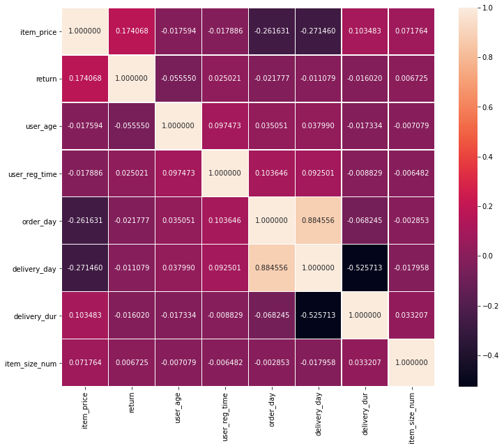

```python
corr= dfk_train.corr()     #to check if some variables correlate and thus convey the same piece of information too much.
f,ax = plt.subplots(figsize=(12, 10))
sns.heatmap(corr ,annot=True,linewidth=.5,fmt='1f');
```

Most of the correlations are insignificant, already explained before or expected due to the way variables are calculated,e.g. delivery dur & delivery day variables. (These two variables will be mentioned in the next section)

This correlation plot was done to see the relationship between the variables and also to get an idea which variables might be important to keep, which variables carry the same information more or less.

```python
num_vars1 = dfk_train.select_dtypes(include=np.float64).columns
dfk_train[num_vars1] = dfk_train[num_vars1].astype(np.float32)

num_vars2 = dfk_train.select_dtypes(include=np.int64).columns
dfk_train[num_vars2] = dfk_train[num_vars2].astype(np.int32)

num_vars3 = dfk_test.select_dtypes(include=np.float64).columns
dfk_test[num_vars3] = dfk_test[num_vars3].astype(np.float32)

num_vars4 = dfk_test.select_dtypes(include=np.int64).columns
dfk_test[num_vars4] = dfk_test[num_vars4].astype(np.int32)

num_vars5 = dfu.select_dtypes(include=np.float64).columns
dfu[num_vars5] = dfu[num_vars5].astype(np.float32)

num_vars6 = dfu.select_dtypes(include=np.int64).columns
dfu[num_vars4] = dfu[num_vars6].astype(np.int32)
```

## Feature Selection Methods

Filter methods are one way to effectively decide on which variables are worth keeping for the model and which are not. Since we have a discrete target variable (either return or keep the product), for the continuous variables we will be basing our decisions on the Fisher score and for the categorical variables on Information Value. Below is the implementation of the Filter methods table.

```python
class filter_binary_target:                    #Implementation of the filter methods table
    def __init__(self, df, target):
        self.target = target
        self.data_head = dfk_train.head()

    def auto_filter_binary_target(self):
        print('Data must be in a clean pandas DataFrame. Categorical variables must be of data type bool or category. Continuous variables must be int64 or float64.')
        data_no_target = dfk_train.drop(columns=self.target)
        columns = ['Data Type', 'Metric', 'Score']
        index = data_no_target.columns
        result = pd.DataFrame(index=index, columns=columns)

        for col in data_no_target:
            if data_no_target.dtypes[col] == 'bool' or data_no_target.dtypes[col].name == 'category':
                result.loc[col, 'Data Type'] = "discrete"
                result.loc[col, 'Metric'] = "IV"
                result.loc[col, 'Score'] = self.IV_binary_target(feature=col)

            if data_no_target.dtypes[col] == 'int32' or data_no_target.dtypes[col] == 'float32':
                result.loc[col, 'Data Type'] = "continuous"
                result.loc[col, 'Metric'] = "Fisher"
                result.loc[col, 'Score'] = self.fisher_binary_target(feature=col)

        return result

    def IV_binary_target(self, feature):
        data = pd.DataFrame()

        data['Count'] = dfk_train[feature].value_counts()
        data['Bad'] = dfk_train.groupby([feature])[self.target].sum()
        data['Good'] = data['Count'] - data['Bad']

        data["Distribution Bad"] = data["Bad"] / data["Bad"].sum()
        data["Distribution Good"] = data["Good"] / data["Good"].sum()

        data['WOE'] = np.log(data["Distribution Good"] / data["Distribution Bad"])
        data.replace({"WOE": {np.inf: 0, -np.inf: 0}})

        data["IV"] = data["WOE"] * (data["Distribution Good"] - data["Distribution Bad"])

        iv = data["IV"].sum()

        return iv

    def fisher_binary_target(self, feature):
        mu_0 = dfk_train.groupby(dfk_train[self.target])[feature].mean()[0]
        mu_1 = dfk_train.groupby(dfk_train[self.target])[feature].mean()[1]
        var_0 = dfk_train.groupby(dfk_train[self.target])[feature].var()[0]
        var_1 = dfk_train.groupby(dfk_train[self.target])[feature].var()[1]

        num = abs(mu_0 - mu_1)
        den = (var_0 + var_1) ** 0.5
        score = num/den

        return score
```

```python
dfk_all = pd.concat([dfk_train, dfk_test]) #, axis=1, join="inner")
dfk_all.head()
```

|  | item_id | item_color | brand_id | item_price | user_title | user_state | return | user_age | user_reg_time | order_day | delivery_day | delivery_dur | item_size_cat | item_size_num |
| --- | --- | --- | --- | --- | --- | --- | --- | --- | --- | --- | --- | --- | --- | --- |
| 2 | 270 | grey | 49 | 0.598029 | Mrs | Baden-Wuerttemberg | 1 | -0.728799 | 1.119513 | 1.588901 | 1.437021 | -0.175918 | xxl | -0.184952 |
| 3 | 142 | grey | 49 | 0.981662 | Mrs | Baden-Wuerttemberg | 0 | -0.728799 | 1.119513 | 1.588901 | 1.437021 | -0.175918 | xxl | -0.184952 |
| 5 | 579 | grey | 3 | -1.285924 | Mrs | Baden-Wuerttemberg | 1 | -0.728799 | 1.119513 | 1.588901 | 1.437021 | -0.175918 | xxl | -0.184952 |
| 6 | 72 | grey | 1 | 1.314432 | Mrs | Baden-Wuerttemberg | 0 | -0.728799 | 1.119513 | 1.588901 | 1.437021 | -0.175918 | numeric | 0.178792 |
| 8 | 195 | blue | 46 | -1.652637 | Mrs | Baden-Wuerttemberg | 1 | -0.728799 | 1.119513 | 1.588901 | 1.437021 | -0.175918 | xxl | -0.184952 |

```python
filter = filter_binary_target(df=dfk_all, target="return") #while deciding on which variables to use it makes more sense to make use of
                                     #as much data as possible. Thus, both test and training sets are used in the calculations.
filter.auto_filter_binary_target()
```

```
Data must be in a clean pandas DataFrame. Categorical variables must be of data type bool or category. Continuous variables must be int64 or float64.
```

|  | Data Type | Metric | Score |
| --- | --- | --- | --- |
| item_id | discrete | IV | inf |
| item_color | discrete | IV | inf |
| brand_id | discrete | IV | inf |
| item_price | continuous | Fisher | 0.249887 |
| user_title | discrete | IV | 0.000980559 |
| user_state | discrete | IV | 0.00250982 |
| user_age | continuous | Fisher | 0.0786915 |
| user_reg_time | continuous | Fisher | 0.0354006 |
| order_day | continuous | Fisher | 0.0308043 |
| delivery_day | continuous | Fisher | 0.0156702 |
| delivery_dur | continuous | Fisher | 0.0226571 |
| item_size_cat | discrete | IV | inf |
| item_size_num | continuous | Fisher | 0.00950651 |

**Initial Observation:**

- Excluding the inf values only item price variable came out as important according to the table.
- Inf values need adjustment.

```python
dfk_train_copy = dfk_train.copy() #as a backup for the operation below.
dfk_train_copy2 = dfk_train.copy()

dfk_test_copy = dfk_test.copy()
dfk_test_copy2 = dfk_test.copy()

dfu_copy = dfu.copy()
dfu_copy2 = dfu.copy()

dfk_all_copy = dfk_all.copy()
dfk_all2 = dfk_all.copy()
```

```python
dfk_all_copy=dfk_all2    #for refreshing the data
dfk_all=dfk_all2

dfk_test = dfk_test_copy2
dfk_test_copy = dfk_test_copy2

dfk_train = dfk_train_copy2
dfk_train_copy = dfk_train_copy2
```

Below, inf values will be fixed so that we can learn about how predictive the respective variable is. Also, Weight of Evidence coding will be done, which will be used for categorical variables in all three data sets. Since the calculation of WoE depends on the data set, for all three, it will be calculated seperately.

```python
class IV_Calc_all:   #this code's aim is to fix the inf values and WoE encode the unknown data
    def __init__(self, dfk_all_copy, feature, target):
        self.feature = feature
        self.target = target
        self.data_head = dfk_all_copy.head()

    def count_values(self):
        data = pd.DataFrame()
        data['Count'] = dfk_all_copy[self.feature].value_counts()               # Count instances of each category, create row for each
        data['Bad'] = dfk_all_copy.groupby([self.feature])[self.target].sum()   # Count y=1 instances of that category
        data['Good'] = data['Count'] - data['Bad']                    # Count y=0 instances of that category
        data = data.sort_values(by=["Count"], ascending=False)

        try:
            assert data["Bad"].sum() != 0                               # Check that there are y=1 instances in sample
            assert data["Good"].sum() != 0                              # Check that there are y=0 instances in sample
            assert np.isin(dfk_all_copy[self.target].unique(), [0, 1]).all()      # Check that target includes only 0,1 or True,False
        except:
          print("Error: Target must include 2 binary classes.")
          raise                                                       # Stop running if one of the above conditions is not satisfied

        return data

    def distribution(self):
        data = self.count_values()
        data['Ratio Bad'] = data['Bad'] / data['Count']
        data['Ratio Good'] = data['Good'] / data['Count']
        data["Distribution Bad"] = data["Bad"] / data["Bad"].sum()    # Of all y=0 instances, what percentage are from each category?
        data["Distribution Good"] = data["Good"] / data["Good"].sum() # Of all y=1 instances, what percentage are from each category?
        data = data.sort_values(by=["Count"], ascending=False)
        return data.iloc[:,-2:]

    def woe(self):
        data = self.distribution()
        data['WOE'] = np.log(data["Distribution Good"] / data["Distribution Bad"])
        data.replace({"WOE": {np.inf: 0, -np.inf: 0}})  # If no instances are bad, this will replace values of infinity with 0
        data = data.sort_values(by=["WOE"], ascending=False)
        return data.iloc[:,-1]

    def woe_adj(self):
        data = self.count_values()
        data["WOE_adj"] = np.log(
            ((data["Count"] - data["Bad"] + 0.5) / (data["Count"].sum() - data["Bad"].sum())) /
            ((data["Bad"] + 0.5) / data["Bad"].sum())
            )
        data.replace({"WOE_adj": {np.inf: 0, -np.inf: 0}})
        data = data.sort_values(by=["Count"], ascending=False)
        return data.iloc[:,-1]

    def IV_per_cat(self):
        data = self.distribution()
        data['WOE'] = self.woe()
        data["IV"] = data["WOE"]*(data["Distribution Good"] - data["Distribution Bad"])
        data = data.sort_values(by=["IV"], ascending=False)
        return data.iloc[:,-1]

    def full_summary(self):
        data = self.count_values()
        data['Ratio Bad'] = data['Bad'] / data['Count']
        data['Ratio Good'] = data['Good'] / data['Count']
        data["Distribution Bad"] = data["Bad"] / data["Bad"].sum()
        data["Distribution Good"] = data["Good"] / data["Good"].sum()
        data['WOE'] = self.woe()
        data["WOE_adj"] = self.woe_adj()
        data["IV"] = self.IV_per_cat()
        data = data.sort_values(by=["Count"], ascending=False)
        return data

    def final_assessment(self):
        data = self.full_summary()
        iv = data["IV"].sum() # final IV value
        if iv < .02:
            print("The variable " + self.feature + " is not predictive with an IV of: {}".format(iv))
        elif iv < .1:
            print("The variable " + self.feature + " is weakly predictive with an IV of:{}".format(iv))
        elif iv < .3:
            print("The variable " + self.feature + " is moderately predictive with an IV of:{}".format(iv))
        else :
            print("The variable " + self.feature + " is highly predictive with an IV of: {}".format(iv))
        return iv
```

#### Item Size (categorical)

```python
woe_x = IV_Calc_all(dfk_all_copy, feature="item_size_cat", target="return")
iv_item_id= woe_x.final_assessment()
```

```
The variable item_size_cat is highly predictive with an IV of: inf
```

```python
item_size_cat_table_all=woe_x.full_summary()   #last two values are problematic
item_size_cat_table_all                        #the same data frame will also be used to WoE encode the unknown data
```

|  | Count | Bad | Good | Ratio Bad | Ratio Good | Distribution Bad | Distribution Good | WOE | WOE_adj | IV |
| --- | --- | --- | --- | --- | --- | --- | --- | --- | --- | --- |
| numeric | 40261 | 21864 | 18397 | 0.543057 | 0.456943 | 0.481459 | 0.416787 | -0.144244 | -0.144240 | 0.009328 |
| l | 11234 | 5539 | 5695 | 0.493057 | 0.506943 | 0.121972 | 0.129021 | 0.056185 | 0.056182 | 0.000396 |
| xl | 9959 | 4960 | 4999 | 0.498042 | 0.501958 | 0.109222 | 0.113253 | 0.036242 | 0.036241 | 0.000146 |
| m | 9358 | 4633 | 4725 | 0.495084 | 0.504916 | 0.102021 | 0.107046 | 0.048073 | 0.048071 | 0.000242 |
| xxl | 8090 | 3818 | 4272 | 0.471941 | 0.528059 | 0.084075 | 0.096783 | 0.140765 | 0.140751 | 0.001789 |
| unsized | 4608 | 1398 | 3210 | 0.303385 | 0.696615 | 0.030785 | 0.072723 | 0.859638 | 0.859436 | 0.036052 |
| s | 3619 | 1840 | 1779 | 0.508428 | 0.491572 | 0.040518 | 0.040304 | -0.005304 | -0.005295 | 0.000001 |
| 6+ | 379 | 234 | 145 | 0.617414 | 0.382586 | 0.005153 | 0.003285 | -0.450177 | -0.448870 | 0.000841 |
| 7+ | 277 | 152 | 125 | 0.548736 | 0.451264 | 0.003347 | 0.002832 | -0.167157 | -0.166449 | 0.000086 |
| 5+ | 222 | 125 | 97 | 0.563063 | 0.436937 | 0.002753 | 0.002198 | -0.225193 | -0.224043 | 0.000125 |
| 8+ | 198 | 103 | 95 | 0.520202 | 0.479798 | 0.002268 | 0.002152 | -0.052442 | -0.052035 | 0.000006 |
| 39+ | 189 | 106 | 83 | 0.560847 | 0.439153 | 0.002334 | 0.001880 | -0.216188 | -0.214888 | 0.000098 |
| 40+ | 160 | 106 | 54 | 0.662500 | 0.337500 | 0.002334 | 0.001223 | -0.646045 | -0.641534 | 0.000718 |
| 10+ | 155 | 86 | 69 | 0.554839 | 0.445161 | 0.001894 | 0.001563 | -0.191831 | -0.190408 | 0.000063 |
| 9+ | 153 | 76 | 77 | 0.496732 | 0.503268 | 0.001674 | 0.001744 | 0.041482 | 0.041397 | 0.000003 |
| 38+ | 135 | 79 | 56 | 0.585185 | 0.414815 | 0.001740 | 0.001269 | -0.315686 | -0.313106 | 0.000149 |
| 42+ | 115 | 65 | 50 | 0.565217 | 0.434783 | 0.001431 | 0.001133 | -0.233954 | -0.231667 | 0.000070 |
| 41+ | 100 | 56 | 44 | 0.560000 | 0.440000 | 0.001233 | 0.000997 | -0.212752 | -0.210341 | 0.000050 |
| 4+ | 79 | 38 | 41 | 0.481013 | 0.518987 | 0.000837 | 0.000929 | 0.104396 | 0.103445 | 0.000010 |
| 37+ | 67 | 39 | 28 | 0.582090 | 0.417910 | 0.000859 | 0.000634 | -0.302947 | -0.297987 | 0.000068 |
| xxxl | 66 | 26 | 40 | 0.393939 | 0.606061 | 0.000573 | 0.000906 | 0.459193 | 0.452567 | 0.000153 |
| xs | 31 | 14 | 17 | 0.451613 | 0.548387 | 0.000308 | 0.000385 | 0.222566 | 0.216462 | 0.000017 |
| 36+ | 20 | 13 | 7 | 0.650000 | 0.350000 | 0.000286 | 0.000159 | -0.590629 | -0.559377 | 0.000075 |
| 11+ | 17 | 12 | 5 | 0.705882 | 0.294118 | 0.000264 | 0.000113 | -0.847059 | -0.792571 | 0.000128 |
| 43+ | 16 | 5 | 11 | 0.312500 | 0.687500 | 0.000110 | 0.000249 | 0.816867 | 0.766009 | 0.000114 |
| 3+ | 12 | 7 | 5 | 0.583333 | 0.416667 | 0.000154 | 0.000113 | -0.308062 | -0.281745 | 0.000013 |
| 46+ | 12 | 5 | 7 | 0.416667 | 0.583333 | 0.000110 | 0.000159 | 0.364882 | 0.338565 | 0.000018 |
| 44+ | 9 | 7 | 2 | 0.777778 | 0.222222 | 0.000154 | 0.000045 | -1.224353 | -1.070202 | 0.000133 |
| 45+ | 8 | 3 | 5 | 0.375000 | 0.625000 | 0.000066 | 0.000113 | 0.539236 | 0.480395 | 0.000025 |
| 2+ | 2 | 2 | 0 | 1.000000 | 0.000000 | 0.000044 | 0.000000 | -inf | -1.581028 | inf |
| 12+ | 1 | 1 | 0 | 1.000000 | 0.000000 | 0.000022 | 0.000000 | -inf | -1.070202 | inf |

```python
dfk_all_copy= dfk_all_copy[dfk_all_copy.item_size_cat != ("2+")]
dfk_all_copy= dfk_all_copy[dfk_all_copy.item_size_cat != ("12+")]
```

```python
woe_x = IV_Calc_all(dfk_all_copy, feature="item_size_cat", target="return")
woe_x.final_assessment()
```

```
The variable item_size_cat is weakly predictive with an IV of:0.050918219719606465
```

```
0.050918219719606465
```

When the inf values were omitted, we find the categorical item size column as weakly predictive.

```python
woe_x.full_summary() #Now the inf values at the end, are not there
```

|  | Count | Bad | Good | Ratio Bad | Ratio Good | Distribution Bad | Distribution Good | WOE | WOE_adj | IV |
| --- | --- | --- | --- | --- | --- | --- | --- | --- | --- | --- |
| numeric | 40261 | 21864 | 18397 | 0.543057 | 0.456943 | 0.481490 | 0.416787 | -0.144310 | -0.144306 | 0.009337 |
| l | 11234 | 5539 | 5695 | 0.493057 | 0.506943 | 0.121980 | 0.129021 | 0.056119 | 0.056116 | 0.000395 |
| xl | 9959 | 4960 | 4999 | 0.498042 | 0.501958 | 0.109229 | 0.113253 | 0.036176 | 0.036175 | 0.000146 |
| m | 9358 | 4633 | 4725 | 0.495084 | 0.504916 | 0.102028 | 0.107046 | 0.048007 | 0.048005 | 0.000241 |
| xxl | 8090 | 3818 | 4272 | 0.471941 | 0.528059 | 0.084080 | 0.096783 | 0.140699 | 0.140685 | 0.001787 |
| unsized | 4608 | 1398 | 3210 | 0.303385 | 0.696615 | 0.030787 | 0.072723 | 0.859572 | 0.859370 | 0.036047 |
| s | 3619 | 1840 | 1779 | 0.508428 | 0.491572 | 0.040521 | 0.040304 | -0.005370 | -0.005361 | 0.000001 |
| 6+ | 379 | 234 | 145 | 0.617414 | 0.382586 | 0.005153 | 0.003285 | -0.450243 | -0.448936 | 0.000841 |
| 7+ | 277 | 152 | 125 | 0.548736 | 0.451264 | 0.003347 | 0.002832 | -0.167223 | -0.166515 | 0.000086 |
| 5+ | 222 | 125 | 97 | 0.563063 | 0.436937 | 0.002753 | 0.002198 | -0.225259 | -0.224109 | 0.000125 |
| 8+ | 198 | 103 | 95 | 0.520202 | 0.479798 | 0.002268 | 0.002152 | -0.052508 | -0.052101 | 0.000006 |
| 39+ | 189 | 106 | 83 | 0.560847 | 0.439153 | 0.002334 | 0.001880 | -0.216255 | -0.214954 | 0.000098 |
| 40+ | 160 | 106 | 54 | 0.662500 | 0.337500 | 0.002334 | 0.001223 | -0.646111 | -0.641600 | 0.000718 |
| 10+ | 155 | 86 | 69 | 0.554839 | 0.445161 | 0.001894 | 0.001563 | -0.191897 | -0.190474 | 0.000063 |
| 9+ | 153 | 76 | 77 | 0.496732 | 0.503268 | 0.001674 | 0.001744 | 0.041416 | 0.041331 | 0.000003 |
| 38+ | 135 | 79 | 56 | 0.585185 | 0.414815 | 0.001740 | 0.001269 | -0.315752 | -0.313172 | 0.000149 |
| 42+ | 115 | 65 | 50 | 0.565217 | 0.434783 | 0.001431 | 0.001133 | -0.234020 | -0.231733 | 0.000070 |
| 41+ | 100 | 56 | 44 | 0.560000 | 0.440000 | 0.001233 | 0.000997 | -0.212818 | -0.210408 | 0.000050 |
| 4+ | 79 | 38 | 41 | 0.481013 | 0.518987 | 0.000837 | 0.000929 | 0.104330 | 0.103379 | 0.000010 |
| 37+ | 67 | 39 | 28 | 0.582090 | 0.417910 | 0.000859 | 0.000634 | -0.303013 | -0.298053 | 0.000068 |
| xxxl | 66 | 26 | 40 | 0.393939 | 0.606061 | 0.000573 | 0.000906 | 0.459127 | 0.452501 | 0.000153 |
| xs | 31 | 14 | 17 | 0.451613 | 0.548387 | 0.000308 | 0.000385 | 0.222500 | 0.216396 | 0.000017 |
| 36+ | 20 | 13 | 7 | 0.650000 | 0.350000 | 0.000286 | 0.000159 | -0.590695 | -0.559443 | 0.000075 |
| 11+ | 17 | 12 | 5 | 0.705882 | 0.294118 | 0.000264 | 0.000113 | -0.847125 | -0.792637 | 0.000128 |
| 43+ | 16 | 5 | 11 | 0.312500 | 0.687500 | 0.000110 | 0.000249 | 0.816801 | 0.765943 | 0.000114 |
| 3+ | 12 | 7 | 5 | 0.583333 | 0.416667 | 0.000154 | 0.000113 | -0.308128 | -0.281811 | 0.000013 |
| 46+ | 12 | 5 | 7 | 0.416667 | 0.583333 | 0.000110 | 0.000159 | 0.364816 | 0.338499 | 0.000018 |
| 44+ | 9 | 7 | 2 | 0.777778 | 0.222222 | 0.000154 | 0.000045 | -1.224419 | -1.070268 | 0.000133 |
| 45+ | 8 | 3 | 5 | 0.375000 | 0.625000 | 0.000066 | 0.000113 | 0.539170 | 0.480329 | 0.000025 |
| 2+ | 0 | 0 | 0 | NaN | NaN | 0.000000 | 0.000000 | NaN | 0.028344 | NaN |
| 12+ | 0 | 0 | 0 | NaN | NaN | 0.000000 | 0.000000 | NaN | 0.028344 | NaN |

```python
dfk_train_copy = dfk_train_copy2  #converting the demo data to normal version to avoid omitting
dfk_test_copy = dfk_test_copy2  #some of the values that might matter for the next variables
dfk_all_copy =dfk_all2
```